# Tugas_Praktikum4

# Nomor 1 ( Proses MA(2) )

## Pembangkitan Data

### ( Manual )

```r
set.seed(123)

n1 <- 300
theta1 <- 0.4
theta2 <- 0.6

epsilon <- rnorm(n1 + 2, mean = 0, sd = 1)

Y_manual1 <- numeric(n1)

for (t in 1:n1) {
  Y_manual1[t] <- epsilon[t + 2] +
    theta1 * epsilon[t + 1] +
    theta2 * epsilon[t]
}

Y_manual1 <- ts(Y_manual1)

Y_manual1
```

```
## Time Series:
## Start = 1
## End = 300
## Frequency = 1
##   [1]  1.130351930  0.555885223  1.092716080  1.809085116  1.224514842
##   [6] -0.051655760 -0.916327622 -1.479439852  0.633705298  0.582049364
##  [11]  1.279146060  0.486879592 -0.271105178  1.630986312  0.879111052
##  [16] -0.695329083  0.213419326 -1.372219341 -0.836126728 -0.928779242
##  [21] -1.753888638 -1.270077957 -1.532198429 -2.374043755 -0.211913841
##  [26] -0.523528051 -0.574115463  0.890584017  0.245108028  0.627803158
##  [31]  1.032975601  1.059140862  1.709909873  1.544152779  1.322322404
##  [36]  0.572839503  0.001623244 -0.540003093 -1.030472978 -0.714082670
##  [41] -1.765387450  1.538047058  1.316306573  0.661449795 -0.127351070
##  [46] -1.301674438  0.351572076 -0.051376231  0.687949958  0.022759210
##  [51]  0.097701949  1.334326048  0.295947654  2.247323581 -1.077627154
```

[output cut: 49 more lines]

#### Plot Time Series

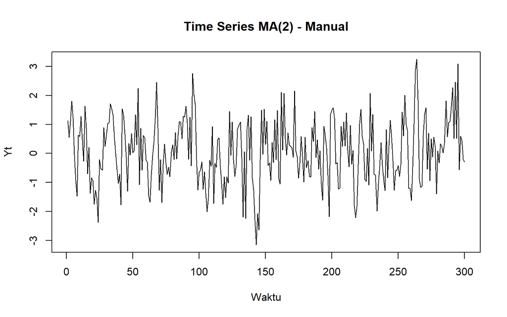

```r
plot(Y_manual1,
     main = "Time Series MA(2) - Manual",
     ylab = "Yt",
     xlab = "Waktu")
```

### arima.sim

```r
set.seed(123)

Y_arima1 <- arima.sim(
  model = list(ma = c(0.4, 0.6)),
  n = 300
)

Y_arima1 <- ts(Y_arima1)

Y_arima1
```

```
## Time Series:
## Start = 1
## End = 300
## Frequency = 1
##   [1]  1.130351930  0.555885223  1.092716080  1.809085116  1.224514842
##   [6] -0.051655760 -0.916327622 -1.479439852  0.633705298  0.582049364
##  [11]  1.279146060  0.486879592 -0.271105178  1.630986312  0.879111052
##  [16] -0.695329083  0.213419326 -1.372219341 -0.836126728 -0.928779242
##  [21] -1.753888638 -1.270077957 -1.532198429 -2.374043755 -0.211913841
##  [26] -0.523528051 -0.574115463  0.890584017  0.245108028  0.627803158
##  [31]  1.032975601  1.059140862  1.709909873  1.544152779  1.322322404
##  [36]  0.572839503  0.001623244 -0.540003093 -1.030472978 -0.714082670
##  [41] -1.765387450  1.538047058  1.316306573  0.661449795 -0.127351070
##  [46] -1.301674438  0.351572076 -0.051376231  0.687949958  0.022759210
##  [51]  0.097701949  1.334326048  0.295947654  2.247323581 -1.077627154
```

[output cut: 49 more lines]

#### Plot time series

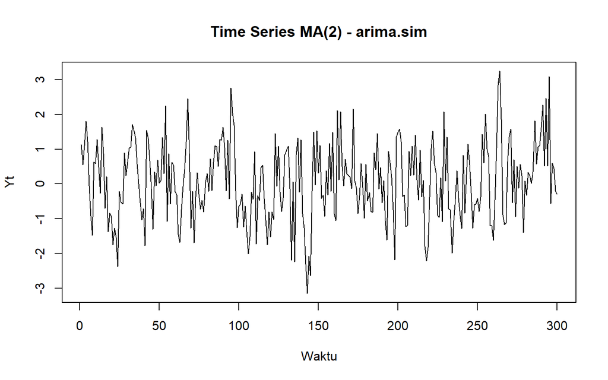

```r
plot(Y_arima1,
     main = "Time Series MA(2) - arima.sim",
     ylab = "Yt",
     xlab = "Waktu")
```

## Plot ACF

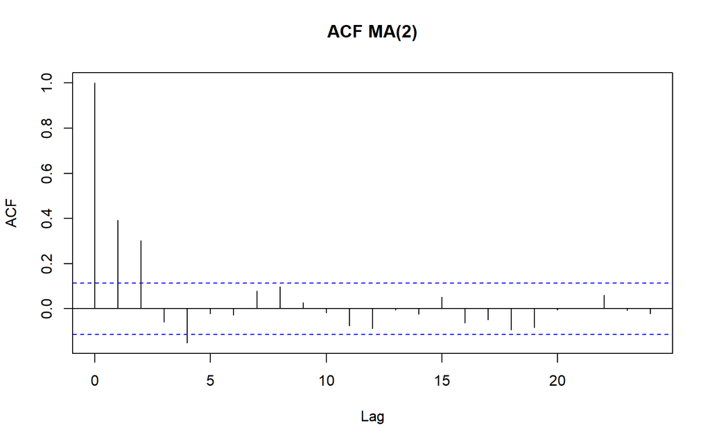

```r
acf(Y_arima1,
    main = "ACF MA(2)")
```

## Plot PACF

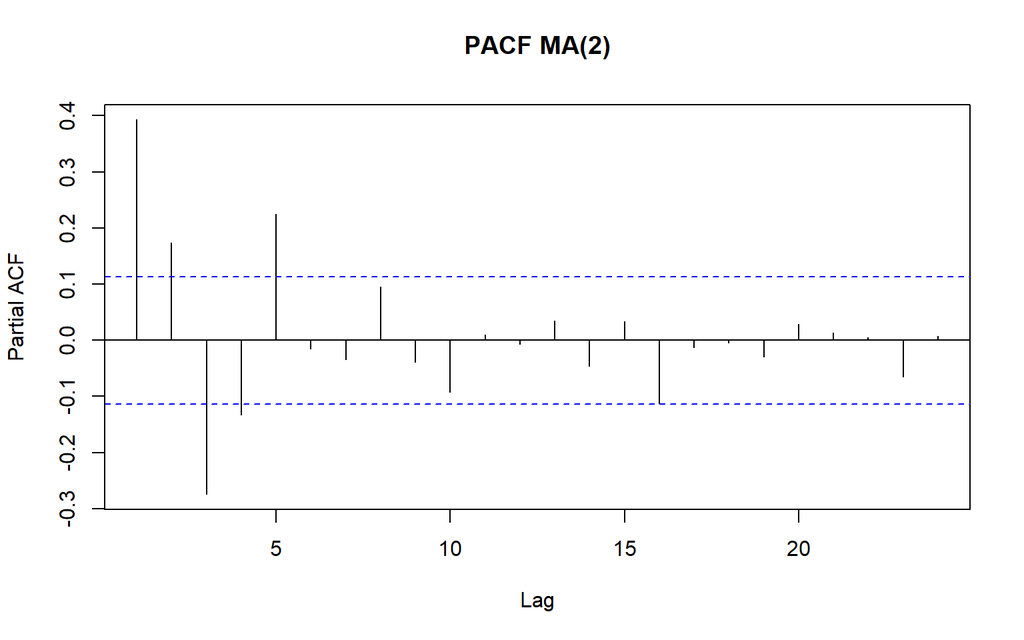

```r
pacf(Y_arima1,
     main = "PACF MA(2)")
```

## Plot EACF

```r
library(TSA)
```

```r
eacf(as.numeric(Y_arima1))
```

```
## AR/MA
##   0 1 2 3 4 5 6 7 8 9 10 11 12 13
## 0 x x o x o o o o o o o  o  o  o
## 1 x x x x o o o o o o o  o  o  o
## 2 x x o x o o o o o o o  o  o  o
## 3 x x o o x o o o o o o  o  o  o
## 4 x x x x x o o o o o o  o  o  o
## 5 o x x x x o o o o o o  o  o  o
## 6 x o x x o o o o o o o  o  o  o
## 7 x x o x x o o o o o o  o  o  o
```

## Scatter Plot

### Yt vs Yt−1

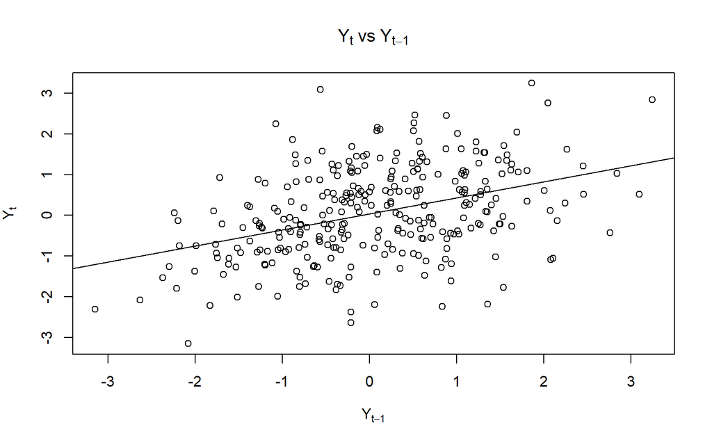

```r
Y <- as.numeric(Y_arima1)

plot(
  Y[-1],
  Y[-length(Y)],
  main = expression(Y[t]~vs~Y[t-1]),
  xlab = expression(Y[t-1]),
  ylab = expression(Y[t])
)

abline(lm(Y[-1] ~ Y[-length(Y)]))
```

### Yt vs Yt−2

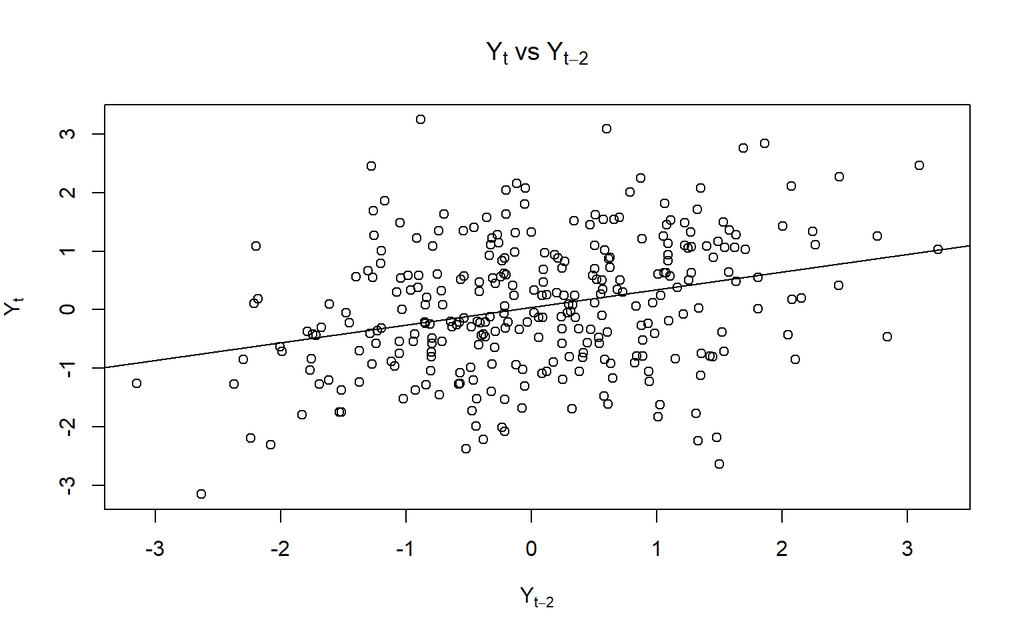

```r
plot(
  Y[-c(1,2)],
  Y[-c(length(Y)-1, length(Y))],
  main = expression(Y[t]~vs~Y[t-2]),
  xlab = expression(Y[t-2]),
  ylab = expression(Y[t])
)

abline(
  lm(Y[-c(1,2)] ~ Y[-c(length(Y)-1, length(Y))])
)
```

### Yt vs Yt−3

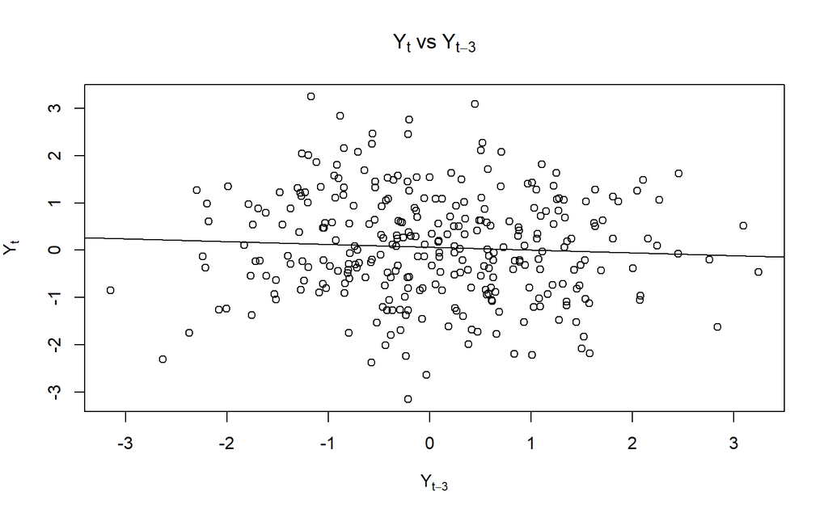

```r
plot(
  Y[-c(1,2,3)],
  Y[-c(length(Y)-2, length(Y)-1, length(Y))],
  main = expression(Y[t]~vs~Y[t-3]),
  xlab = expression(Y[t-3]),
  ylab = expression(Y[t])
)

abline(
  lm(Y[-c(1,2,3)] ~ Y[-c(length(Y)-2, length(Y)-1, length(Y))])
)
```

## Cek Autokorelasi

```r
# Autokorelasi empiris
cor_lag1 <- cor(
  Y_arima1[-1],
  Y_arima1[-length(Y_arima1)]
)

cor_lag2 <- cor(
  Y_arima1[-c(1,2)],
  Y_arima1[-c(length(Y_arima1)-1, length(Y_arima1))]
)

cor_lag3 <- cor(
  Y_arima1[-c(1,2,3)],
  Y_arima1[-c(length(Y_arima1)-2,
             length(Y_arima1)-1,
             length(Y_arima1))]
)

# Autokorelasi teoritis
teoritis <- ARMAacf(
  ma = c(0.4, 0.6),
  lag.max = 3
)

hasil_acf <- data.frame(
  Lag = 1:3,
  Empiris = c(cor_lag1, cor_lag2, cor_lag3),
  Teoritis = teoritis[2:4]
)

hasil_acf
```

```
##   Lag     Empiris  Teoritis
## 1   1  0.39358604 0.4210526
## 2   2  0.30214505 0.3947368
## 3   3 -0.05893345 0.0000000
```

MA(2) memiliki autokorelasi pada lag 1 dan lag 2, dengan nilai empiris masing-masing sebesar 0,3936 dan 0,3021. Sementara itu, pada lag 3 nilai autokorelasi empiris sebesar −0,0589, yang relatif dekat dengan nol.

# Nomor 2 ( Proses AR (2) )

## Pembangkitan Data

### Manual

```r
set.seed(123)

n2 <- 300
phi1 <- 0.5
phi2 <- 0.2

# Bangkitkan error
epsilon <- rnorm(n2)

# Inisialisasi
Y_manual2 <- numeric(n2)

Y_manual2[1] <- epsilon[1]
Y_manual2[2] <- phi1 * Y_manual2[1] + epsilon[2]

# Membentuk AR(2)
for (t in 3:n2) {
  Y_manual2[t] <- phi1 * Y_manual2[t-1] +
    phi2 * Y_manual2[t-2] +
    epsilon[t]
}

Y_manual2 <- ts(Y_manual2)

Y_manual2
```

```
## Time Series:
## Start = 1
## End = 300
## Frequency = 1
##   [1] -0.5604756466 -0.5104153128  1.1914055285  0.5641280931  0.6496328874
##   [6]  2.1527070492  1.6671963081 -0.0009216707 -0.3538744256 -0.6227835171
##  [11]  0.8419151538  0.6562147005  0.8972618316  0.6905565719 -0.0311104825
##  [16]  1.9094692099  1.4463629867 -0.8615418213  0.5598575883 -0.3651709779
##  [21] -1.1384376773 -0.8602279489 -1.6838059582 -1.7428397982 -1.8332203586
##  [26] -2.9518714497 -1.0047927520 -0.9393975481 -1.8087942615  0.1615382807
##  [31]  0.1454745095 -0.1900265721  0.8292072769  1.2547318116  1.6147884428
##  [36]  1.7469808378  1.7503657610  1.1626673375  0.6254441572  0.1647845451
##  [41] -0.4872258749 -0.4185733065 -1.5721281798  1.2991772141  1.5431249694
##  [46] -0.0917106557 -0.1401151692 -0.5550550694  0.4744145498  0.0428271946
##  [51]  0.3696150212  0.1648261942  0.1134656440  1.4583003449  0.5260723156
```

[output cut: 49 more lines]

#### Plot time series

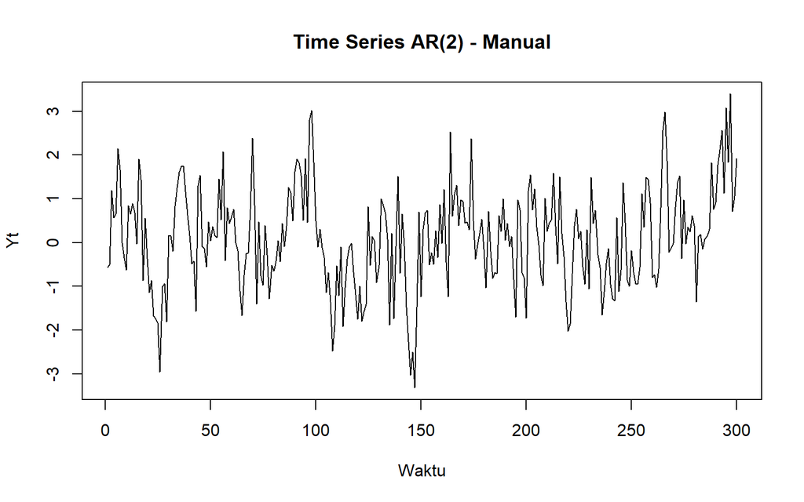

```r
plot(Y_manual2,
     main = "Time Series AR(2) - Manual",
     ylab = "Yt",
     xlab = "Waktu")
```

### arima.sim

```r
set.seed(123)

Y_arima2 <- arima.sim(
  model = list(ar = c(0.5, 0.2)),
  n = 300
)

Y_arima2 <- ts(Y_arima2)

Y_arima2
```

```
## Time Series:
## Start = 1
## End = 300
## Frequency = 1
##   [1] -2.9518714497 -1.0047927520 -0.9393975481 -1.8087942615  0.1615382807
##   [6]  0.1454745095 -0.1900265721  0.8292072769  1.2547318116  1.6147884428
##  [11]  1.7469808378  1.7503657610  1.1626673375  0.6254441572  0.1647845451
##  [16] -0.4872258749 -0.4185733065 -1.5721281798  1.2991772141  1.5431249694
##  [21] -0.0917106557 -0.1401151692 -0.5550550694  0.4744145498  0.0428271946
##  [26]  0.3696150212  0.1648261942  0.1134656440  1.4583003449  0.5260723156
##  [31]  2.0711668312 -0.4079549255  0.7948696531  0.4396980853  0.5947645420
##  [36]  0.7649613708 -0.0008898593 -0.1806600391 -1.1090833745 -1.6624649216
##  [41] -0.7495204943 -0.2590434528 -0.2264215985  0.7572479780  2.3834243549
##  [46]  0.8521306070 -1.4064187011  0.4729552953 -0.7540068552 -0.9704209850
##  [51]  0.3895595062 -0.2840774510 -1.2848445365 -0.5179342787 -0.6548274091
```

[output cut: 49 more lines]

#### Plot time series

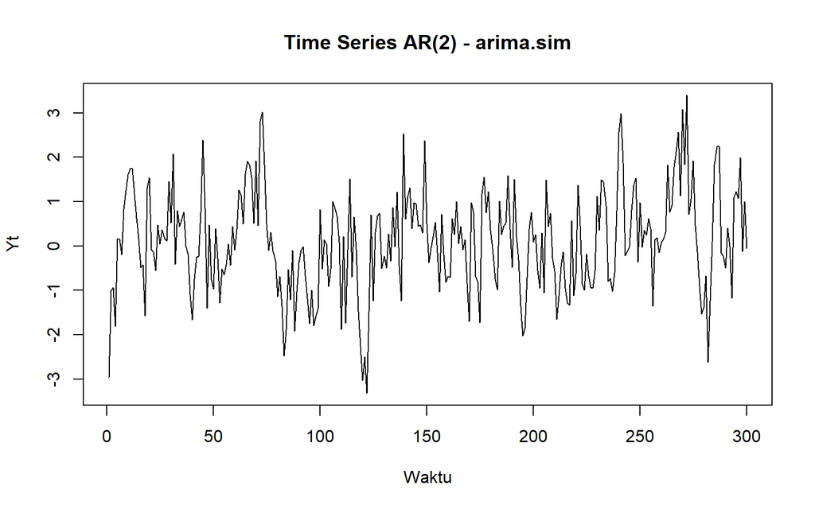

```r
plot(Y_arima2,
     main = "Time Series AR(2) - arima.sim",
     ylab = "Yt",
     xlab = "Waktu")
```

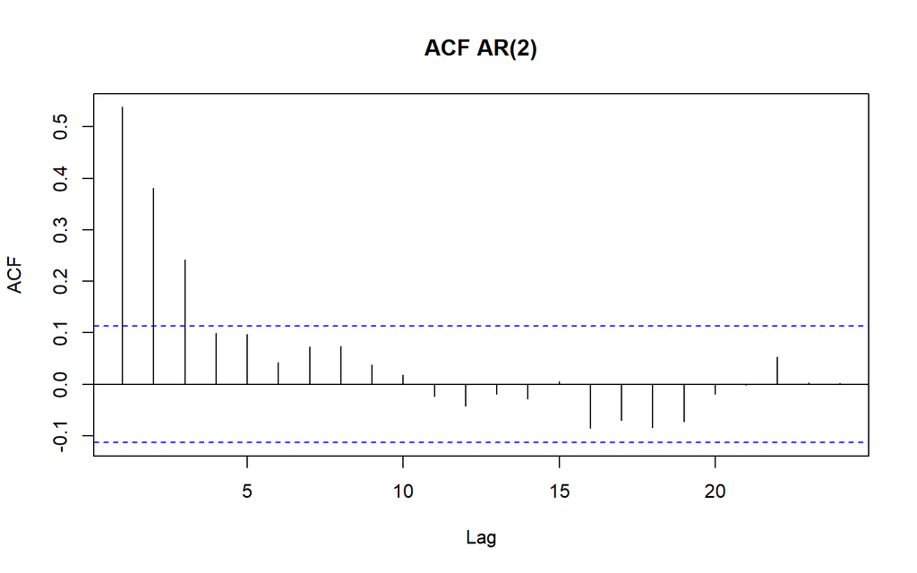

```r
acf(Y_arima2,
    main = "ACF AR(2)")
```

## Plot PACF

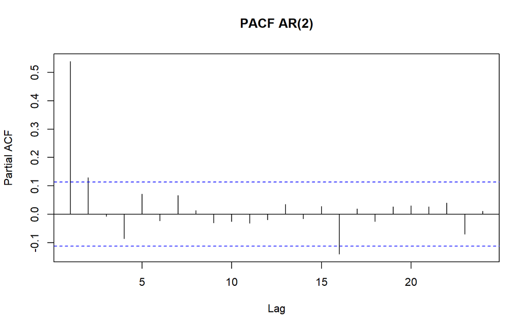

```r
pacf(Y_arima2,
     main = "PACF AR(2)")
```

## Plot EACF

```r
eacf(Y_arima2)
```

```
## AR/MA
##   0 1 2 3 4 5 6 7 8 9 10 11 12 13
## 0 x x x o o o o o o o o  o  o  o
## 1 x o o x o o o o o o o  o  o  o
## 2 o o o o o o o o o o o  o  o  o
## 3 o x o o o o o o o o o  o  o  o
## 4 x x o o o x o o o o o  o  o  o
## 5 x x o x o o o o o o o  o  o  o
## 6 x x o x x o o o o o o  o  o  o
## 7 x x x x x o o o o o o  o  o  o
```

## Scatter Plot

### Yt vs Yt−1

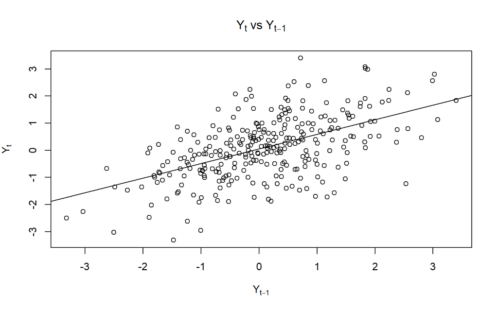

```r
Y <- as.numeric(Y_arima2)

plot(
  Y[-1],
  Y[-length(Y)],
  main = expression(Y[t]~vs~Y[t-1]),
  xlab = expression(Y[t-1]),
  ylab = expression(Y[t])
)

abline(
  lm(Y[-1] ~ Y[-length(Y)])
)
```

### Yt vs Yt−2

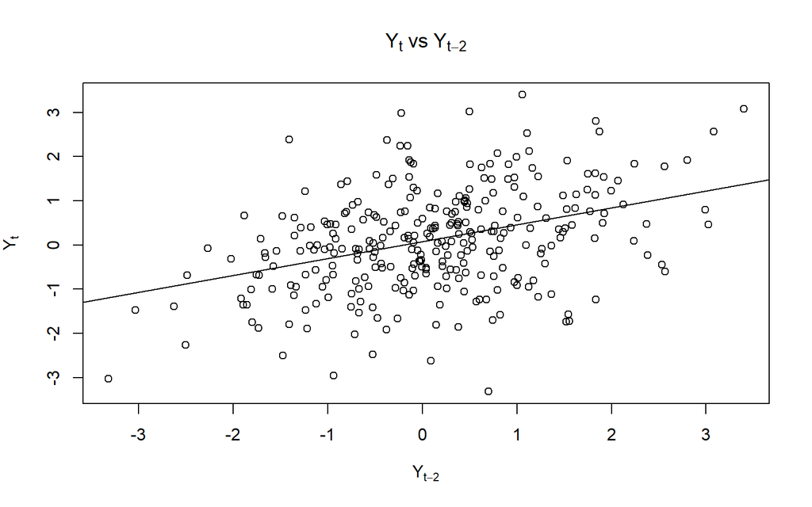

```r
plot(
  Y[-c(1,2)],
  Y[-c(length(Y)-1, length(Y))],
  main = expression(Y[t]~vs~Y[t-2]),
  xlab = expression(Y[t-2]),
  ylab = expression(Y[t])
)

abline(
  lm(Y[-c(1,2)] ~ Y[-c(length(Y)-1, length(Y))])
)
```

### Yt vs Yt−3

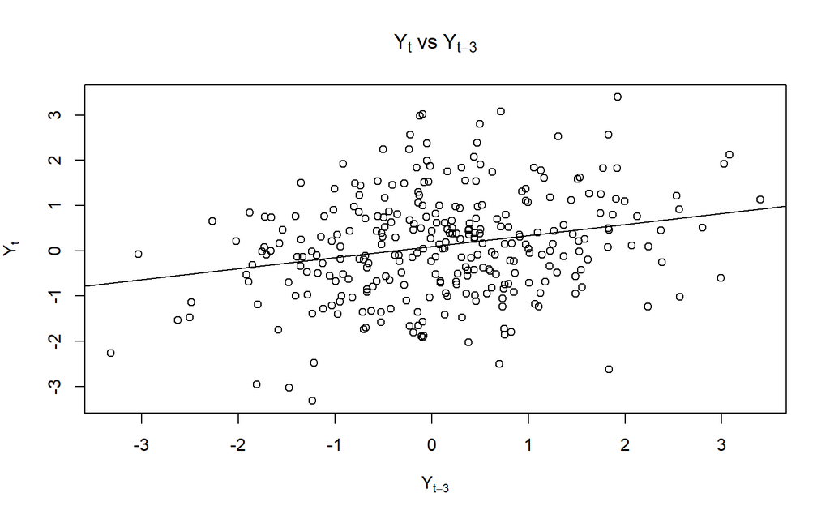

```r
plot(
  Y[-c(1,2,3)],
  Y[-c(length(Y)-2,
       length(Y)-1,
       length(Y))],
  main = expression(Y[t]~vs~Y[t-3]),
  xlab = expression(Y[t-3]),
  ylab = expression(Y[t])
)

abline(
  lm(Y[-c(1,2,3)] ~
       Y[-c(length(Y)-2,
            length(Y)-1,
            length(Y))])
)
```

## Cek Autokorelasi

```r
# Autokorelasi empiris
cor_lag1 <- cor(
  Y_arima2[-1],
  Y_arima2[-length(Y_arima2)]
)
cor_lag2 <- cor(
  Y_arima2[-c(1,2)],
  Y_arima2[-c(length(Y_arima2)-1, length(Y_arima2))]
)

cor_lag3 <- cor(
  Y_arima2[-c(1,2,3)],
  Y_arima2[-c(length(Y_arima2)-2,
             length(Y_arima2)-1,
             length(Y_arima2))]
)

# Autokorelasi teoritis AR(2)
teoritis <- ARMAacf(
  ar = c(0.5, 0.2),
  lag.max = 3
)

# Tabel perbandingan
hasil_acf <- data.frame(
  Lag = 1:3,
  Empiris = c(cor_lag1, cor_lag2, cor_lag3),
  Teoritis = teoritis[2:4]
)

hasil_acf
```

```
##   Lag   Empiris Teoritis
## 1   1 0.5448227  0.62500
## 2   2 0.3867911  0.51250
## 3   3 0.2464424  0.38125
```

AR(2) memiliki autokorelasi positif pada lag 1, lag 2, dan lag 3, dengan nilai empiris masing-masing sebesar 0,5448, 0,3868, dan 0,2464.

# Nomor 3 ( Proses ARMA(2,2) )

## Pembangkitan Data

### Manual

```r
set.seed(123)

n <- 300

phi1 <- 0.5
phi2 <- 0.2

theta1 <- 0.4
theta2 <- 0.6

epsilon <- rnorm(n)

Y_manual3 <- numeric(n)

Y_manual3[1] <- epsilon[1]

Y_manual3[2] <-
  phi1 * Y_manual3[1] +
  epsilon[2]

for (t in 3:n) {
  Y_manual3[t] <-
    phi1 * Y_manual3[t-1] +
    phi2 * Y_manual3[t-2] +
    epsilon[t] +
    theta1 * epsilon[t-1] +
    theta2 * epsilon[t-2]
}

Y_manual3 <- ts(Y_manual3)

Y_manual3
```

```
## Time Series:
## Start = 1
## End = 300
## Frequency = 1
##   [1] -0.560475647 -0.510415313  0.763049145  0.835326733  1.662989276
##   [6]  2.807645100  2.960935247  1.990340884  0.671029869 -0.745856740
##  [11]  0.394982902  0.630369467  1.673327374  1.449617173  0.788368883
##  [16]  2.315094189  2.194331923  0.864855716  1.084713568 -0.656891414
##  [21] -0.947629721 -1.533972385 -2.710400775 -2.932072822 -3.540314994
##  [26] -4.730615817 -3.285284748 -3.112293588 -2.787319207 -1.125534304
##  [31] -0.875122966 -0.034865185  0.840518415  1.472427033  2.614227073
##  [36]  3.145751722  3.418043680  2.911011688  2.140737824  1.112568157
##  [41] -0.046041335 -0.514589706 -2.031890570  0.419183832  1.119520375
##  [46]  1.305046749  0.749076380 -0.666126898  0.168323903 -0.100439659
##  [51]  0.671394909  0.338368733  0.401165297  1.602582443  1.177471935
```

[output cut: 49 more lines]

### Plot Time Series

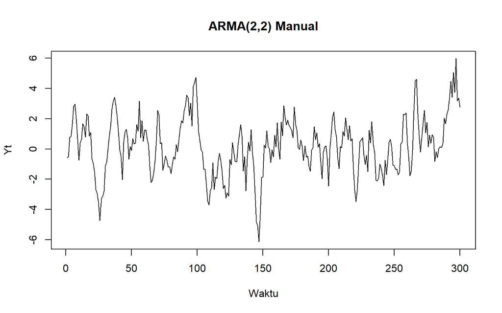

```r
plot(Y_manual3,
     main = "ARMA(2,2) Manual",
     ylab = "Yt",
     xlab = "Waktu")
```

### Arima.sim

```r
set.seed(123)

Y_arima3 <- arima.sim(
  model = list(
    ar = c(phi1, phi2),
    ma = c(theta1, theta2)
  ),
  n = 300
)

Y_arima3 <- ts(Y_arima3)
Y_arima3
```

```
## Time Series:
## Start = 1
## End = 300
## Frequency = 1
##   [1] -3.111871501 -2.786997430 -1.125288998 -0.874935957 -0.034722620
##   [6]  0.840627099  1.472509888  2.614290237  3.145799875  3.418080389
##  [11]  2.911039673  2.140759158  1.112584421 -0.046028935 -0.514580254
##  [16] -2.031883364  0.419189325  1.119524563  1.305049942  0.749078814
##  [21] -0.666125042  0.168325317 -0.100438581  0.671395731  0.338369360
##  [26]  0.401165775  1.602582807  1.177472212  3.156576248  0.736155413
##  [31]  1.874387947  0.512873117  1.247565664  1.266686112  0.661953470
##  [36]  0.277960882 -1.181881273 -2.214494270 -2.079956469 -1.556330589
##  [41] -0.779751265  0.511253275  2.550470593  2.259849141  0.364488158
##  [46]  0.421666182 -1.408675956 -0.988250548 -0.451013000 -0.710506239
##  [51] -1.164739812 -1.202318563 -1.632907842 -0.997927905 -0.521294263
```

[output cut: 49 more lines]

#### Plot time series

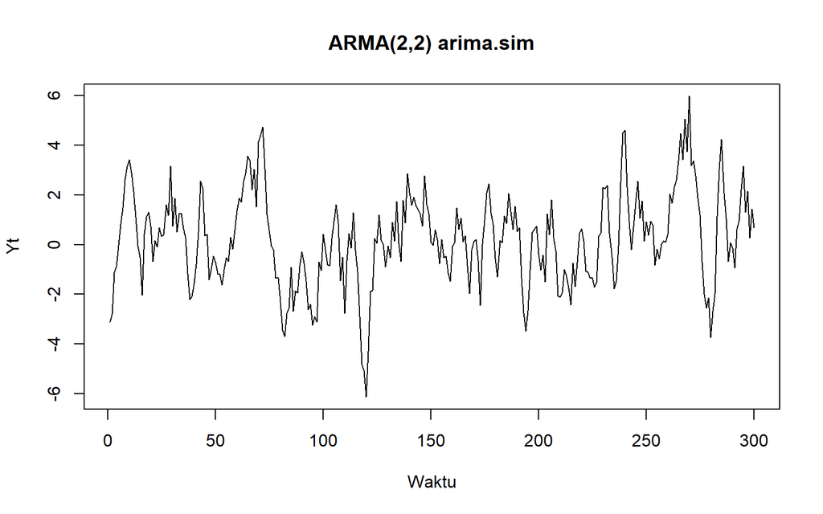

```r
plot(Y_arima3,
     main = "ARMA(2,2) arima.sim",
     ylab = "Yt",
     xlab = "Waktu")
```

## Plot ACF

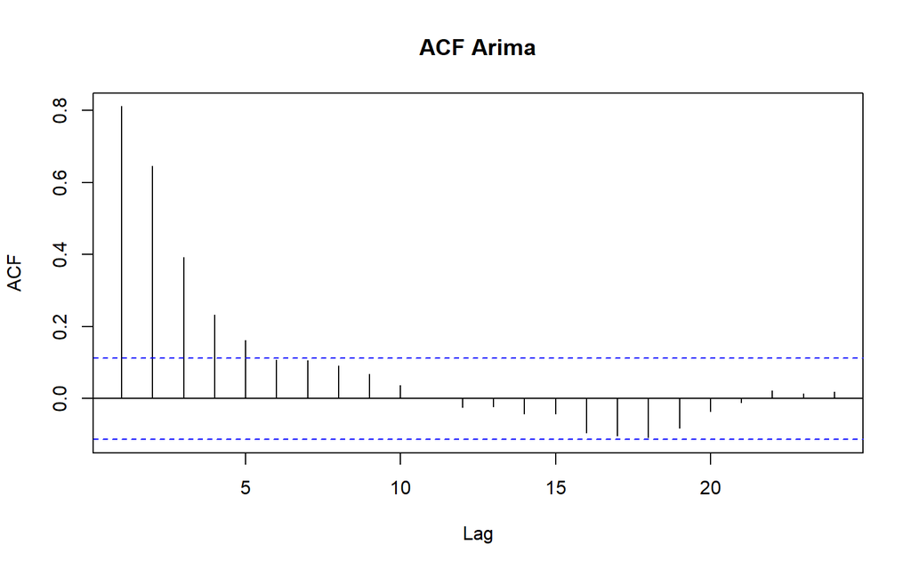

```r
acf(Y_arima3,
    main = "ACF Arima")
```

## Plot PACF

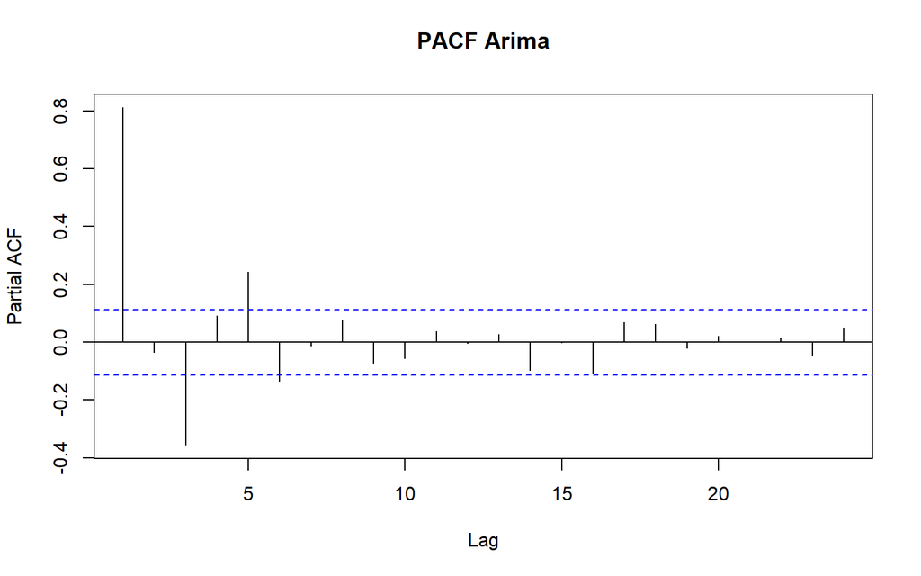

```r
pacf(Y_arima3,
     main = "PACF Arima")
```

## Plot EACF

```r
eacf(Y_arima3)
```

```
## AR/MA
##   0 1 2 3 4 5 6 7 8 9 10 11 12 13
## 0 x x x x x o o o o o o  o  o  o
## 1 o x o o o x o o o o o  o  o  o
## 2 o x o o o x o o o o o  o  o  o
## 3 x x o x o x o o o o o  o  o  o
## 4 x x o x o x o o o o o  o  o  o
## 5 x x o x x o o o o o o  o  o  o
## 6 x x o x x o o o o o o  o  o  o
## 7 x x x x x o o o o o o  o  o  o
```

## Scatter Plot

### Yt vs Yt−1

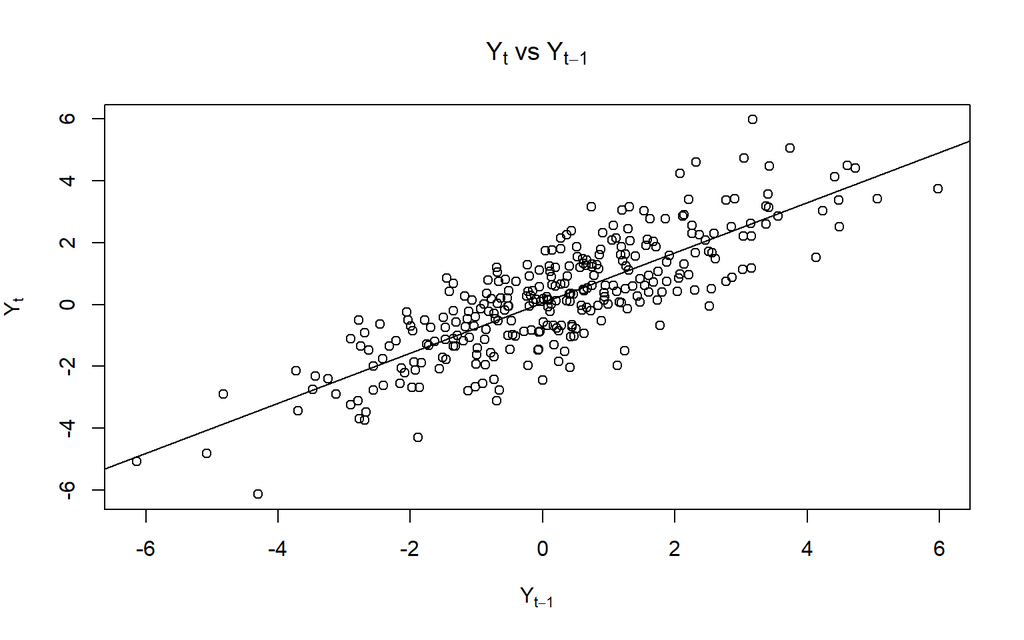

```r
Y <- as.numeric(Y_arima3)

plot(
  Y[-1],
  Y[-length(Y)],
  main = expression(Y[t]~vs~Y[t-1]),
  xlab = expression(Y[t-1]),
  ylab = expression(Y[t])
)

abline(
  lm(Y[-1] ~ Y[-length(Y)])
)
```

### Yt vs Yt−2

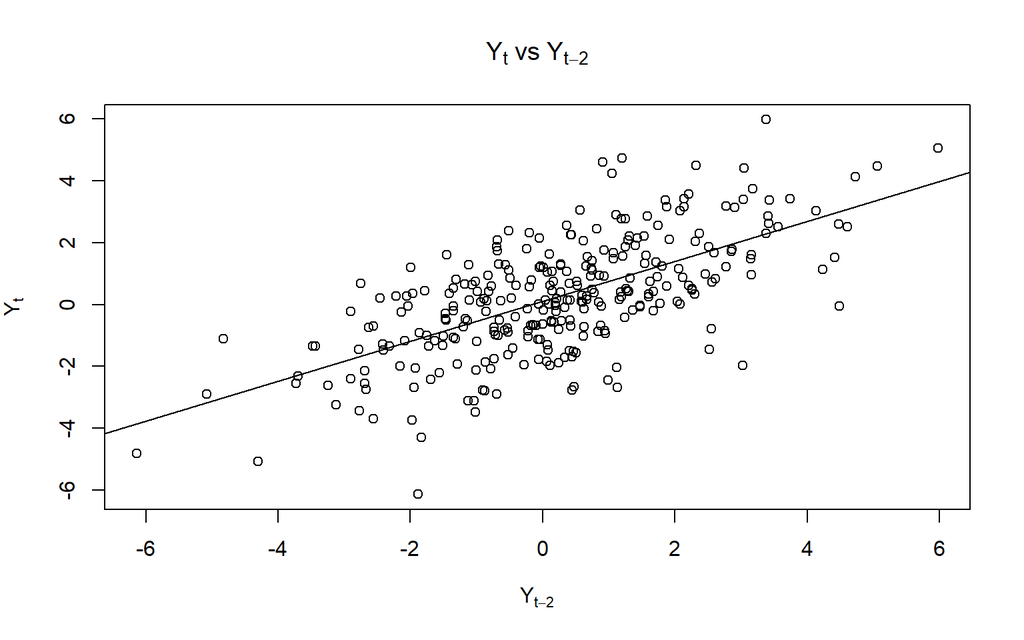

```r
plot(
  Y[-c(1,2)],
  Y[-c(length(Y)-1, length(Y))],
  main = expression(Y[t]~vs~Y[t-2]),
  xlab = expression(Y[t-2]),
  ylab = expression(Y[t])
)

abline(
  lm(
    Y[-c(1,2)] ~
      Y[-c(length(Y)-1, length(Y))]
  )
)
```

### Yt vs Yt−3

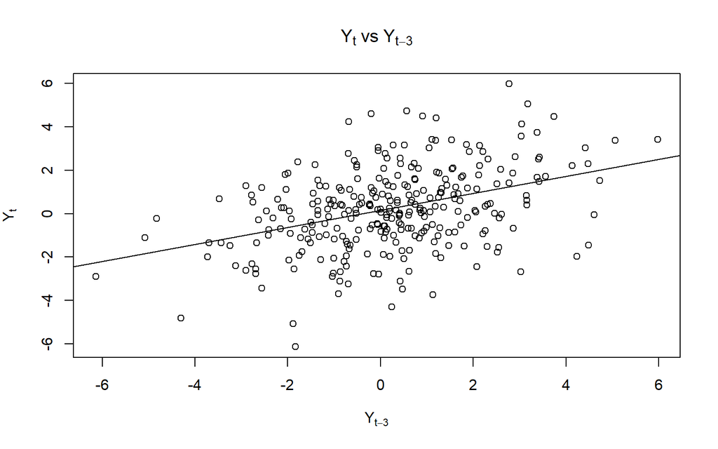

```r
plot(
  Y[-c(1,2,3)],
  Y[-c(length(Y)-2,
       length(Y)-1,
       length(Y))],
  main = expression(Y[t]~vs~Y[t-3]),
  xlab = expression(Y[t-3]),
  ylab = expression(Y[t])
)

abline(
  lm(
    Y[-c(1,2,3)] ~
      Y[-c(length(Y)-2,
            length(Y)-1,
            length(Y))]
  )
)
```

## Cek Autokorelasi

```r
# Autokorelasi  empiris
cor_lag1 <- cor(
  Y_arima3[-1],
  Y_arima3[-length(Y_arima3)]
)

cor_lag2 <- cor(
  Y_arima3[-c(1,2)],
  Y_arima3[-c(length(Y_arima3)-1, length(Y_arima3))]
)

cor_lag3 <- cor(
  Y_arima3[-c(1,2,3)],
  Y_arima3[-c(length(Y_arima3)-2,
             length(Y_arima3)-1,
             length(Y_arima3))]
)

# Autokorelasi teoritis
teoritis <- ARMAacf(
  ar = c(0.5, 0.2),
  ma = c(0.4, 0.6),
  lag.max = 3
)
hasil_acf3 <- data.frame(
  Lag = 1:3,
  Empiris = c(cor_lag1, cor_lag2, cor_lag3),
  Teoritis = teoritis[2:4]
)

hasil_acf3
```

```
##   Lag   Empiris  Teoritis
## 1   1 0.8152280 0.8591993
## 2   2 0.6523184 0.7491908
## 3   3 0.3962500 0.5464353
```

Berdasarkan hasil perhitungan autokorelasi, nilai autokorelasi empiris pada lag 1, 2, dan 3 berturut-turut sebesar 0,8152, 0,6523, dan 0,3963. Nilai tersebut menunjukkan adanya autokorelasi positif pada ketiga lag, dengan kekuatan hubungan yang semakin menurun seiring bertambahnya lag.